# Multiple Linear Regression

## Problem Statement

Use Multiple Linear Regression to **predict the consumption of petrol** given relevant variables are the petrol tax, the per capita, income, the number of miles of paved highway, and the proportion of the population with driver's licenses.

## Dataset

There are 48 rows of data. The data include:

```
  I,  the index;
  A1, the petrol tax;
  A2, the per capita income;
  A3, the number of miles of paved highway;
  A4, the proportion of drivers;
  B,  the consumption of petrol.
```

### Reference

```
Helmut Spaeth,
Mathematical Algorithms for Linear Regression,
Academic Press, 1991,
ISBN 0-12-656460-4.

S Weisberg,
Applied Linear Regression,
New York, 1980, pages 32-33.
```

## Question 1 - Exploratory Data Analysis

*Read the dataset given in file named **'petrol.csv'**. Check the statistical details of the dataset.*

**Hint:** You can use **df.describe()**

```python
import pandas as pd
import seaborn as sns
import matplotlib.pyplot as plt
%matplotlib inline

import numpy as np

from sklearn.linear_model import LinearRegression
```

```python
petrol_df = pd.read_csv('petrol-1.csv')
```

```python
petrol_df.info()
```

```
<class 'pandas.core.frame.DataFrame'>
RangeIndex: 48 entries, 0 to 47
Data columns (total 5 columns):
tax            48 non-null float64
income         48 non-null int64
highway        48 non-null int64
dl             48 non-null float64
consumption    48 non-null int64
dtypes: float64(2), int64(3)
memory usage: 2.0 KB
```

```python
petrol_df.head(10)
```

|  | tax | income | highway | dl | consumption |
| --- | --- | --- | --- | --- | --- |
| 0 | 9.0 | 3571 | 1976 | 0.525 | 541 |
| 1 | 9.0 | 4092 | 1250 | 0.572 | 524 |
| 2 | 9.0 | 3865 | 1586 | 0.580 | 561 |
| 3 | 7.5 | 4870 | 2351 | 0.529 | 414 |
| 4 | 8.0 | 4399 | 431 | 0.544 | 410 |
| 5 | 10.0 | 5342 | 1333 | 0.571 | 457 |
| 6 | 8.0 | 5319 | 11868 | 0.451 | 344 |
| 7 | 8.0 | 5126 | 2138 | 0.553 | 467 |
| 8 | 8.0 | 4447 | 8577 | 0.529 | 464 |
| 9 | 7.0 | 4512 | 8507 | 0.552 | 498 |

```python
petrol_df.tail(10)
```

|  | tax | income | highway | dl | consumption |
| --- | --- | --- | --- | --- | --- |
| 38 | 8.5 | 3635 | 3274 | 0.663 | 648 |
| 39 | 7.0 | 4345 | 3905 | 0.672 | 968 |
| 40 | 7.0 | 4449 | 4639 | 0.626 | 587 |
| 41 | 7.0 | 3656 | 3985 | 0.563 | 699 |
| 42 | 7.0 | 4300 | 3635 | 0.603 | 632 |
| 43 | 7.0 | 3745 | 2611 | 0.508 | 591 |
| 44 | 6.0 | 5215 | 2302 | 0.672 | 782 |
| 45 | 9.0 | 4476 | 3942 | 0.571 | 510 |
| 46 | 7.0 | 4296 | 4083 | 0.623 | 610 |
| 47 | 7.0 | 5002 | 9794 | 0.593 | 524 |

```python
petrol_df.sample(5)
```

|  | tax | income | highway | dl | consumption |
| --- | --- | --- | --- | --- | --- |
| 9 | 7.00 | 4512 | 8507 | 0.552 | 498 |
| 35 | 6.58 | 3802 | 7834 | 0.629 | 644 |
| 4 | 8.00 | 4399 | 431 | 0.544 | 410 |
| 1 | 9.00 | 4092 | 1250 | 0.572 | 524 |
| 18 | 7.00 | 4716 | 5915 | 0.724 | 865 |

```python
petrol_df.describe().transpose()
```

|  | count | mean | std | min | 25% | 50% | 75% | max |
| --- | --- | --- | --- | --- | --- | --- | --- | --- |
| tax | 48.0 | 7.668333 | 0.950770 | 5.000 | 7.00000 | 7.5000 | 8.12500 | 10.000 |
| income | 48.0 | 4241.833333 | 573.623768 | 3063.000 | 3739.00000 | 4298.0000 | 4578.75000 | 5342.000 |
| highway | 48.0 | 5565.416667 | 3491.507166 | 431.000 | 3110.25000 | 4735.5000 | 7156.00000 | 17782.000 |
| dl | 48.0 | 0.570333 | 0.055470 | 0.451 | 0.52975 | 0.5645 | 0.59525 | 0.724 |
| consumption | 48.0 | 576.770833 | 111.885816 | 344.000 | 509.50000 | 568.5000 | 632.75000 | 968.000 |

```python
# finding the modes
petrol_df.mode()
```

|  | tax | income | highway | dl | consumption |
| --- | --- | --- | --- | --- | --- |
| 0 | 7.0 | 5126.0 | 7834.0 | 0.525 | 464.0 |
| 1 | NaN | NaN | NaN | 0.529 | 524.0 |
| 2 | NaN | NaN | NaN | 0.544 | 566.0 |
| 3 | NaN | NaN | NaN | 0.563 | 577.0 |
| 4 | NaN | NaN | NaN | 0.571 | 640.0 |
| 5 | NaN | NaN | NaN | 0.572 | NaN |
| 6 | NaN | NaN | NaN | 0.586 | NaN |
| 7 | NaN | NaN | NaN | 0.663 | NaN |
| 8 | NaN | NaN | NaN | 0.672 | NaN |

proportion of drivers and consumption of petrol are multi moded

```python
petrol_df.isnull().sum()
```

```
tax            0
income         0
highway        0
dl             0
consumption    0
dtype: int64
```

```python
petrol_df.isna().sum()
```

```
tax            0
income         0
highway        0
dl             0
consumption    0
dtype: int64
```

There are no null or missing values

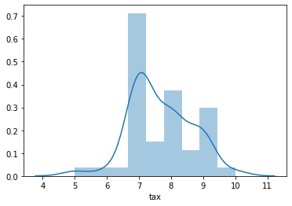

```python
sns.distplot(petrol_df['tax'])
```

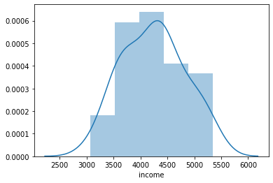

```python
sns.distplot(petrol_df['income'])
```

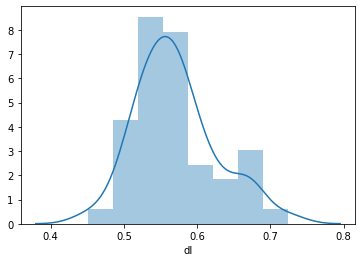

```python
sns.distplot(petrol_df['dl'])
```

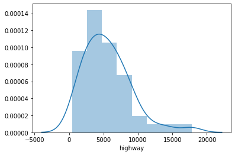

```python
sns.distplot(petrol_df['highway'])
```

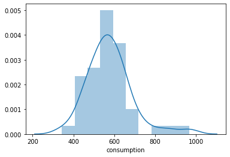

```python
sns.distplot(petrol_df['consumption'])
```

# Question 2 - Cap outliers

Find the outliers and cap them. (Use (Q1 - 1.5 *IQR) as the minimum cap and (Q3 + 1.5* IQR) as the max cap. The decision criteria is you should consider the datapoints which only falls within this range. The data points which fall outside this range are outliers and the entire row needs to be removed

```python
import numpy as np
Q1 = petrol_df.quantile(0.25)
Q3 = petrol_df.quantile(0.75)
IQR = Q3 - Q1
print("IQR:")
print(IQR,"\n")

print("Outlier details:\n")
print(petrol_df[petrol_df<(Q1-1.5*IQR)].dropna(how='all'),"\n")
print(petrol_df[petrol_df>(Q3+1.5*IQR)].dropna(how='all'))
```

```
IQR:
tax               1.1250
income          839.7500
highway        4045.7500
dl                0.0655
consumption     123.2500
dtype: float64

Outlier details:

    tax  income  highway  dl  consumption
36  5.0     NaN      NaN NaN          NaN

     tax  income  highway     dl  consumption
5   10.0     NaN      NaN    NaN          NaN
11   NaN     NaN  14186.0    NaN          NaN
18   NaN     NaN      NaN  0.724        865.0
36   NaN     NaN  17782.0    NaN          NaN
39   NaN     NaN      NaN    NaN        968.0
```

### Identifying the same using boxplot

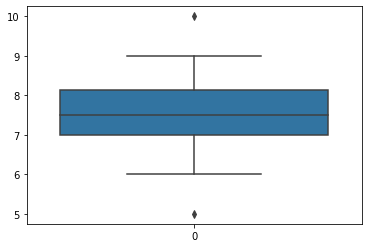

```python
sns.boxplot(data=petrol_df.tax)
```

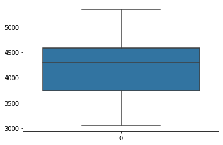

```python
sns.boxplot(data=petrol_df.income)
```

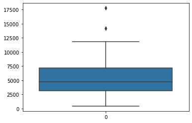

```python
sns.boxplot(data=petrol_df.highway)
```

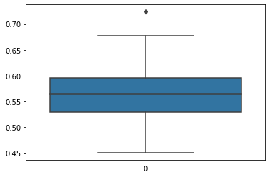

```python
sns.boxplot(data=petrol_df.dl)
```

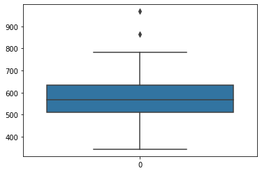

```python
sns.boxplot(data=petrol_df.consumption)
```

Clearly a|ll columns except income has outliers

#### Removing all rows which has atleast one outlier

```python
petrol_df_out =  petrol_df[~((petrol_df < (Q1-1.5*IQR))|(petrol_df > (Q3 + 1.5*IQR))).any(axis=1)]
petrol_df_out.shape
```

```
(43, 5)
```

# Question 3 - Independent variables and collinearity

Which attributes seems to have stronger association with the dependent variable consumption?

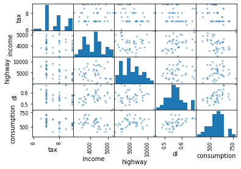

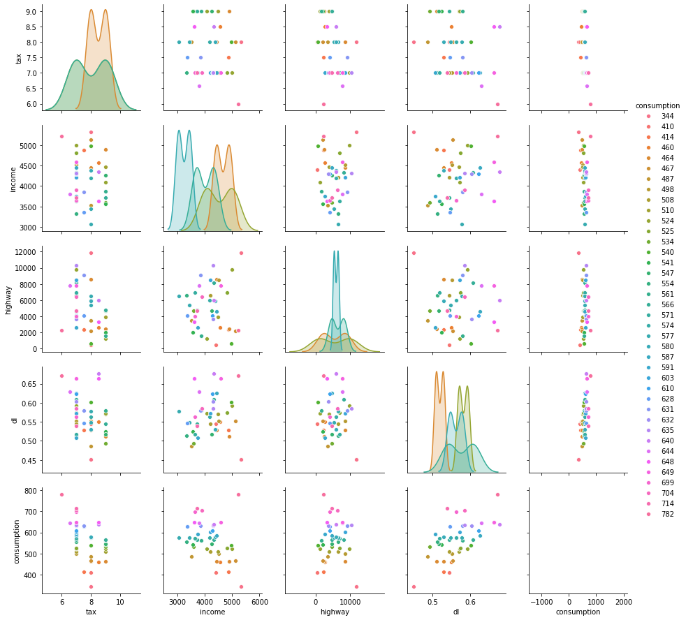

```python
pd.plotting.scatter_matrix(petrol_df_out)
sns.pairplot(petrol_df_out,hue='consumption')
```

```python
petrol_df_out.corr()['consumption']
```

```
tax           -0.446116
income        -0.347326
highway        0.034309
dl             0.611788
consumption    1.000000
Name: consumption, dtype: float64
```

Observing the above correlation values between all the variables, we can see that there is stronger association between the number of drivers and consumption. And comparatively tax has an association in a negative way.

Insights :

As tax increases the consumption decreases.

As income increases consumption decreases

As number of drivers is more consumption is more---strongly correlated

# Question 4 - Transform the dataset

Divide the data into feature(X) and target(Y) sets.

```python
# Copy all the predictor variables into X dataframe.
X1 = petrol_df_out[['dl','tax']]

# Copy the 'mpg' column alone into the y dataframe. This is the dependent variable
y1 = petrol_df_out[['consumption']]
```

```python
X1.shape
```

```
(43, 2)
```

```python
y1.shape
```

```
(43, 1)
```

# Question 5 - Split data into train, test sets

Divide the data into training and test sets with 80-20 split using scikit-learn. Print the shapes of training and test feature sets.

```python
from sklearn.model_selection import train_test_split
```

```python
# Split X and y into training and test set in 80:20 ratio

X1_train, X1_test, y1_train, y1_test = train_test_split(X1, y1, test_size=0.20, random_state=1)
```

# Question 6 - Build Model

Estimate the coefficients for each input feature. Construct and display a dataframe with coefficients and X.columns as columns

```python
# invoke the LinearRegression function and find the bestfit model on training data

regression_model = LinearRegression()
regression_model.fit(X1_train, y1_train)
```

```
LinearRegression(copy_X=True, fit_intercept=True, n_jobs=None, normalize=False)
```

```python
# coefficients for each of the independent attributes

for idx, col_name in enumerate(X1_train.columns):
    print("The coefficient for {} is {}".format(col_name, regression_model.coef_[0][idx]))
```

```
The coefficient for dl is 892.8862087487328
The coefficient for tax is -30.70924254754726
```

```python
# intercept for the model

intercept = regression_model.intercept_[0]

print("The intercept for our model is {}".format(intercept))
```

```
The intercept for our model is 292.55096524614925
```

#### Our linear model is:

##### Y = 892.886*x1 - 30.709*x2 + 292.550

# Question 7 - Evaluate the model

Calculate the accuracy score for the above model.

```python
# Model score - R2 or coeff of determinant
# R^2=1–RSS / TSS

regression_model.score(X1_test, y1_test)
```

```
0.2876056314158516
```

```python
# The model explains 28.7% of the variability in Y using X
```

```python
# Let us check the sum of squared errors by predicting value of y for test cases and
# subtracting from the actual y for the test cases

mse = np.mean((regression_model.predict(X1_test)-y1_test)**2)
print(mse)
```

```
consumption    4764.247277
dtype: float64
```

```python
# underroot of mean_sq_error is standard deviation i.e. avg variance between predicted and actual

import math

math.sqrt(mse)
```

```
69.02352698398606
```

There is an avg of 69.02 (roundoff) consumption difference from real consumption on an avg

```python
# predict consumption for a set of attributes not in the training or test set
y1_pred = regression_model.predict(X1_test)
```

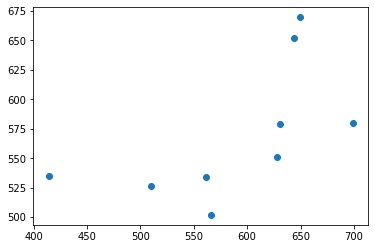

```python
# plotting predicted y value vs actual y values for the test data
# A good model's prediction will be close to actual leading to high R and R2 values
plt.scatter(y1_test, y1_pred)
```

```python
# finding the r2 score
from sklearn.metrics import r2_score
r2_score(y1_test,y1_pred)
```

```
0.2876056314158516
```

# Question 8: Repeat the same Multi linear regression modelling by adding both Income and Highway features

Find R2

```python
# Copy all the predictor variables into X dataframe.
X2 = petrol_df_out[['dl','tax','income','highway']]

# Copy the 'mpg' column alone into the y dataframe. This is the dependent variable
y2 = petrol_df_out[['consumption']]
```

```python
X2.shape
```

```
(43, 4)
```

```python
y2.shape
```

```
(43, 1)
```

```python
# Split X and y into training and test set in 80:20 ratio

X2_train, X2_test, y2_train, y2_test = train_test_split(X2, y2, test_size=0.20, random_state=1)
```

```python
# invoke the LinearRegression function and find the bestfit model on training data

regression_model2 = LinearRegression()
regression_model2.fit(X2_train, y2_train)
```

```
LinearRegression(copy_X=True, fit_intercept=True, n_jobs=None, normalize=False)
```

```python
# coefficients for each of the independent attributes

for idx, col_name in enumerate(X2_train.columns):
    print("The coefficient for {} is {}".format(col_name, regression_model2.coef_[0][idx]))
```

```
The coefficient for dl is 950.882744143261
The coefficient for tax is -39.411583621419304
The coefficient for income is -0.06262814005687746
The coefficient for highway is -0.00302198703957725
```

```python
# intercept for the model

intercept = regression_model2.intercept_[0]

print("The intercept for our model is {}".format(intercept))
```

```
The intercept for our model is 607.7189089086053
```

##### Our linear model is:

###### 950.882*x1-39.411*x2-0.062*x3-0.003*x4+607.71

```python
# Model score - R2 or coeff of determinant
# R^2=1–RSS / TSS

regression_model2.score(X2_test, y2_test)
```

```
0.6930212207091713
```

```python
# The model explains 69.3% of the variability in Y using X
```

```python
# Let us check the sum of squared errors by predicting value of y for test cases and
# subtracting from the actual y for the test cases

mse = np.mean((regression_model2.predict(X2_test)-y2_test)**2)
print(mse)
```

```
consumption    2052.96796
dtype: float64
```

```python
# underroot of mean_sq_error is standard deviation i.e. avg variance between predicted and actual

import math

math.sqrt(mse)
```

```
45.30968946898472
```

There is an avg of 45.30 (roundoff) consumption difference from real consumption on an avg

```python
# predict consumption for a set of attributes not in the training or test set
y2_pred = regression_model2.predict(X2_test)
```

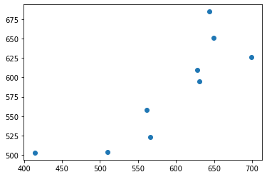

```python
# plotting predicted y value vs actual y values for the test data
# A good model's prediction will be close to actual leading to high R and R2 values
plt.scatter(y2_test, y2_pred)
```

```python
# r2 score
r2_score(y2_test,y2_pred)
```

```
0.6930212207091713
```

# Question 9: Print the coefficients of the multilinear regression model

```python
#Model1-considering tax and driver alone

for idx, col_name in enumerate(X1_train.columns):
    print("The coefficient for {} is {}".format(col_name, regression_model.coef_[0][idx]))
```

```
The coefficient for dl is 892.8862087487328
The coefficient for tax is -30.70924254754726
```

```python
#Model2-considering income ad  highway as   well

for idx, col_name in enumerate(X2_train.columns):
    print("The coefficient for {} is {}".format(col_name, regression_model2.coef_[0][idx]))
```

```
The coefficient for dl is 950.882744143261
The coefficient for tax is -39.411583621419304
The coefficient for income is -0.06262814005687746
The coefficient for highway is -0.00302198703957725
```

# Question 10

In one or two sentences give reasoning on R-Square on the basis of above findings Answer

##### Multilinear regression model created considering all four features tax, number of drivers, income and highway is better than the model created cosidering tax and number of drivers alone considering the R2 score